# Practica 2

## 3 Limpieza de datos

### 3.1 ¿Los datos contienen ceros o elementos vacíos?

Se va a evaluar cada variable para comprobar si hay elementos vacíos o ceros. En cada caso se procederá a cambiar los elementos vacíos por un valor y los valores cero se comprobará que son correctos o no. En caso negativo, se procederá a cambiar el valor por el mismo procedimiento que el caso de elemento vacío.

#### Survived

```r
#Se comprueban si hay valores vacíos
which(is.na(base2$Survived))
```

```
## integer(0)
```

```r
#En este caso no hay valores nulos
table(base2$Survived)
```

```
##
##   0   1
## 549 342
```

```r
#Se comprueba que ha valores cero debido a que corresponde a la gente que no sobrevive
```

#### PClass

```r
#Se comprueban si hay valores vacíos
which(is.na(base2$Pclass))
```

```
## integer(0)
```

```r
#En este caso no hay valores nulos
#Se comprueba que no hay valores cero.
table(base2$Pclass)
```

```
##
##   1   2   3
## 216 184 491
```

```r
#Todos los datos se agrupan en los valores establecidos 1,2 y 3.
```

#### Sex

```r
#Se comprueban si hay valores vacíos
which(is.na(base2$Sex))
```

```
## integer(0)
```

```r
#En este caso no hay valores nulos
#Se comprueba que no hay valores cero.
table(base2$Sex)
```

```
##
## female   male
##    314    577
```

```r
#Todos los datos se agrupan en los valores establecidos hombre y mujer
```

#### Age

```r
#Se comprueban si hay valores vacíos
sel <- which(is.na(base2$Age))
sel
```

```
##   [1]   6  18  20  27  29  30  32  33  37  43  46  47  48  49  56  65  66  77
##  [19]  78  83  88  96 102 108 110 122 127 129 141 155 159 160 167 169 177 181
##  [37] 182 186 187 197 199 202 215 224 230 236 241 242 251 257 261 265 271 275
##  [55] 278 285 296 299 301 302 304 305 307 325 331 335 336 348 352 355 359 360
##  [73] 365 368 369 376 385 389 410 411 412 414 416 421 426 429 432 445 452 455
##  [91] 458 460 465 467 469 471 476 482 486 491 496 498 503 508 512 518 523 525
## [109] 528 532 534 539 548 553 558 561 564 565 569 574 579 585 590 594 597 599
## [127] 602 603 612 613 614 630 634 640 644 649 651 654 657 668 670 675 681 693
## [145] 698 710 712 719 728 733 739 740 741 761 767 769 774 777 779 784 791 793
## [163] 794 816 826 827 829 833 838 840 847 850 860 864 869 879 889
```

```r
#En este caso hay valores vacíos y se procede a cambiar por la mediana de los datos
base2[sel,"Age"]<-median(base2$Age,na.rm = T)
#Se vuelve a comprobar si hay valores vacíos
which(is.na(base2$Age))
```

```
## integer(0)
```

```r
#No hay valores vacíos
#Se comprueba que no hay valores cero.
which(base2$Age==0)
```

```
## integer(0)
```

```r
table(base2$Age)
```

```
##
## 0.42 0.67 0.75 0.83 0.92    1    2    3    4    5    6    7    8    9   10   11
##    1    1    2    2    1    7   10    6   10    4    3    3    4    8    2    4
##   12   13   14 14.5   15   16   17   18   19   20 20.5   21   22   23 23.5   24
##    1    2    6    1    5   17   13   26   25   15    1   24   27   15    1   30
## 24.5   25   26   27   28 28.5   29   30 30.5   31   32 32.5   33   34 34.5   35
##    1   23   18   18  202    2   20   25    2   17   18    2   15   15    1   18
##   36 36.5   37   38   39   40 40.5   41   42   43   44   45 45.5   46   47   48
##   22    1    6   11   14   13    2    6   13    5    9   12    2    3    9    9
##   49   50   51   52   53   54   55 55.5   56   57   58   59   60   61   62   63
##    6   10    7    6    1    8    2    1    4    2    5    2    4    3    4    2
##   64   65   66   70 70.5   71   74   80
##    2    3    1    2    1    2    1    1
```

```r
#Se comprueba que no hay valores igual a cero y los que hay cercanos a cero son correctos porque en el buque hubo bebes de meses embarcados.
```

#### SibSp

```r
#Se comprueban si hay valores vacíos
which(is.na(base2$SibSp))
```

```
## integer(0)
```

```r
#En este caso no hay valores vacíos
#Se comprueba que si hay valores cero.
table(base2$SibSp)
```

```
##
##   0   1   2   3   4   5   8
## 608 209  28  16  18   5   7
```

```r
#Se comprueba que hay valores igual a cero pero es razonable porque puede haber pasajeros que no tengan hermanos o cónyuges embarcados.
```

#### Parch

```r
#Se comprueban si hay valores vacíos
which(is.na(base2$Parch))
```

```
## integer(0)
```

```r
#En este caso no hay valores vacíos
#Se comprueba que si hay valores cero.
table(base2$Parch)
```

```
##
##   0   1   2   3   4   5   6
## 678 118  80   5   4   5   1
```

```r
#Se comprueba que hay valores igual a cero pero es razonable porque puede haber pasajeros que no tengan hijos o padres embarcados.
```

#### Fare

```r
#Se comprueban si hay valores vacíos
which(is.na(base2$Fare))
```

```
## integer(0)
```

```r
#En este caso no hay valores vacíos
#Se comprueba que si hay valores cero.
sel1 <- which(base2$Fare==0)
sel1
```

```
##  [1] 180 264 272 278 303 414 467 482 598 634 675 733 807 816 823
```

```r
#Se comprueba que hay valores igual a cero pero no es razonable siendo substituidos por la mediana
base2[sel1,"Fare"]<-median(base2$Fare,na.rm = T)
#Se comprueba que se hizo correctamente el cambio
which(base2$Fare==0)
```

```
## integer(0)
```

#### Embarked

```r
#Se comprueban si hay valores vacíos
sel2 <- which(base2$Embarked!="C" & base2$Embarked!="S" & base2$Embarked!="Q")
sel2
```

```
## [1]  62 830
```

```r
#Se cambian estos valores por el primer puerto S = Southampton
base2$Embarked[sel2]<-"S"
base2[sel2,]
```

```
##     Survived Pclass    Sex Age SibSp Parch Fare Embarked
## 62         1      1 female  38     0     0   80        S
## 830        1      1 female  62     0     0   80        S
```

```r
#Se comprueba que se hizo correctamente el cambio
which(base2$Embarked!="C" & base2$Embarked!="S" & base2$Embarked!="Q")
```

```
## integer(0)
```

```r
table(base2$Embarked)
```

```
##
##   C   Q   S
## 168  77 646
```

Se convierten las variables survived, pclass, sex y embarked.

```r
#Se convierten en factores las variables survived, pclass, sex y embarked.
base2$Survived <- as.factor(base2$Survived)
base2$Pclass <- as.factor(base2$Pclass)
base2$Sex <- as.factor(base2$Sex)
base2$Embarked <- as.factor(base2$Embarked)
#Se vuelve a comprobar que los tipos de variables son acordes
str(base2)
```

```
## 'data.frame':    891 obs. of  8 variables:
##  $ Survived: Factor w/ 2 levels "0","1": 1 2 2 2 1 1 1 1 2 2 ...
##  $ Pclass  : Factor w/ 3 levels "1","2","3": 3 1 3 1 3 3 1 3 3 2 ...
##  $ Sex     : Factor w/ 2 levels "female","male": 2 1 1 1 2 2 2 2 1 1 ...
##  $ Age     : num  22 38 26 35 35 28 54 2 27 14 ...
##  $ SibSp   : int  1 1 0 1 0 0 0 3 0 1 ...
##  $ Parch   : int  0 0 0 0 0 0 0 1 2 0 ...
##  $ Fare    : num  7.25 71.28 7.92 53.1 8.05 ...
##  $ Embarked: Factor w/ 3 levels "C","Q","S": 3 1 3 3 3 2 3 3 3 1 ...
```

###3.2.Identificación y tratamiento de valores extremos.

Se va a comprobar los valores extremos para las variables age y fare debido a que las demás variables son factores o se comprobó que no hay valores extraños en el anterior apartado.

#### Age

```r
#Se va a comprobar los valores estadísticos
summary(base2$Age)
```

```
##    Min. 1st Qu.  Median    Mean 3rd Qu.    Max.
##    0.42   22.00   28.00   29.36   35.00   80.00
```

```r
print("Varianza")
```

```
## [1] "Varianza"
```

```r
var(base2$Age)
```

```
## [1] 169.5125
```

```r
print("Desviación")
```

```
## [1] "Desviación"
```

```r
sd(base2$Age)
```

```
## [1] 13.0197
```

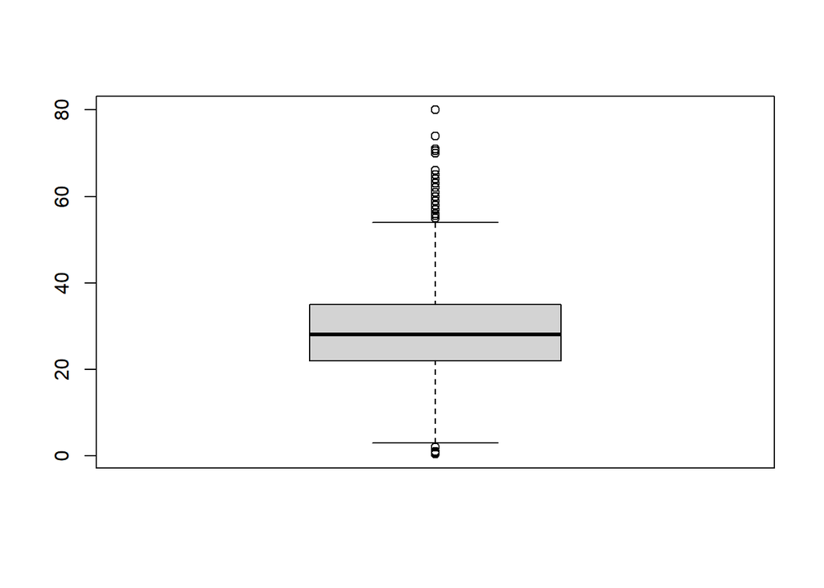

```r
#Se va a hacer un gráfico de cajas para ver los valores
boxplot(base2$Age)
```

```r
#Se comprueban que hay valores extremos, se procede a ver estos valores
boxplot.stats(base2$Age)$out
```

```
##  [1]  2.00 58.00 55.00  2.00 66.00 65.00  0.83 59.00 71.00 70.50  2.00 55.50
## [13]  1.00 61.00  1.00 56.00  1.00 58.00  2.00 59.00 62.00 58.00 63.00 65.00
## [25]  2.00  0.92 61.00  2.00 60.00  1.00  1.00 64.00 65.00 56.00  0.75  2.00
## [37] 63.00 58.00 55.00 71.00  2.00 64.00 62.00 62.00 60.00 61.00 57.00 80.00
## [49]  2.00  0.75 56.00 58.00 70.00 60.00 60.00 70.00  0.67 57.00  1.00  0.42
## [61]  2.00  1.00 62.00  0.83 74.00 56.00
```

```r
#Estos valores son válidos porque pudo haber pasajeros con esta edad.
```

#### Fare

```r
#Se va a comprobar los valores estadísticos
summary(base2$Fare)
```

```
##    Min. 1st Qu.  Median    Mean 3rd Qu.    Max.
##   4.013   7.925  14.454  32.447  31.000 512.329
```

```r
print("Varianza")
```

```
## [1] "Varianza"
```

```r
var(base2$Fare)
```

```
## [1] 2457.208
```

```r
print("Desviación")
```

```
## [1] "Desviación"
```

```r
sd(base2$Fare)
```

```
## [1] 49.57024
```

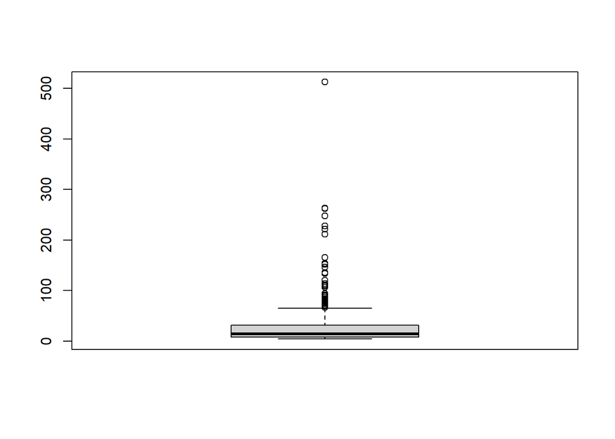

```r
#Se va a hacer un gráfico de cajas para ver los valores
boxplot(base2$Fare)
```

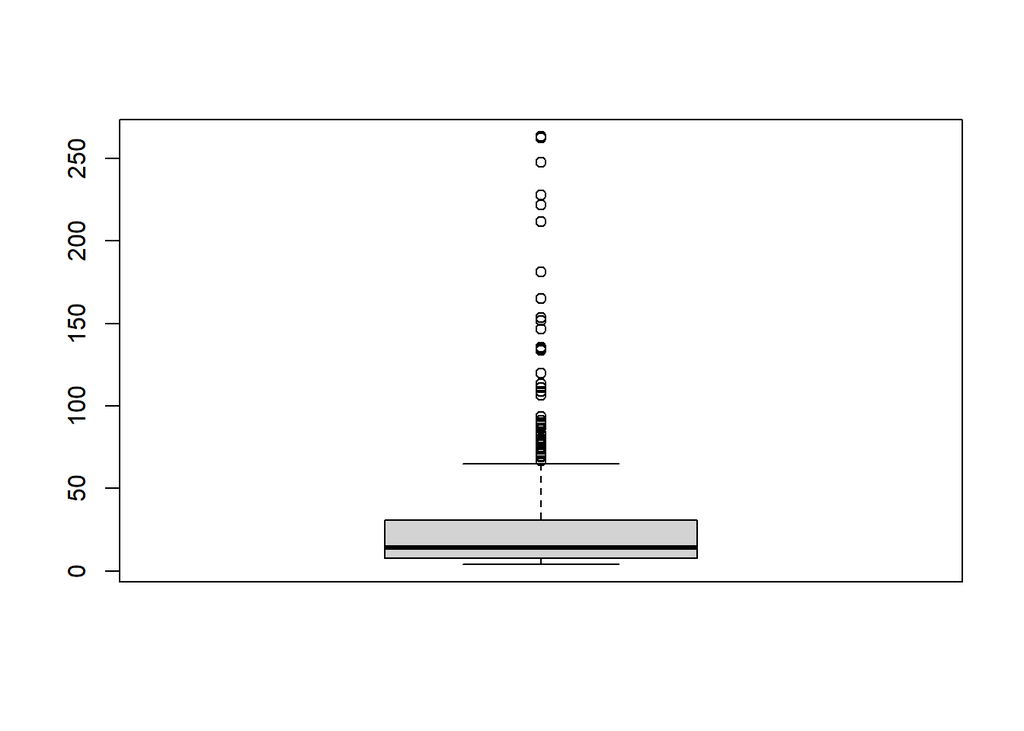

```r
#Se comprueban que hay valores extremos siendo uno muy llamativo (cercano a 500)
#Se procede a cambiar este valor por la media mas 3 veces la desviación
maxi <- max(base2$Fare)
base2$Fare[base2$Fare==max(base2$Fare)] <- mean(base2$Fare)+3*sd(base2$Fare)
#Se procede a comprobar de nuevo el gráfico
boxplot(base2$Fare)
```

```r
boxplot.stats(base2$Fare)$out
```

```
##   [1]  71.2833 263.0000 146.5208  82.1708  76.7292  80.0000  83.4750  73.5000
##   [9] 263.0000  77.2875 247.5208  73.5000  77.2875  79.2000  66.6000  69.5500
##  [17]  69.5500 146.5208  69.5500 113.2750  76.2917  90.0000  83.4750  90.0000
##  [25]  79.2000  86.5000 181.1583  79.6500 153.4625 135.6333  77.9583  78.8500
##  [33]  91.0792 151.5500 247.5208 151.5500 110.8833 108.9000  83.1583 262.3750
##  [41] 164.8667 134.5000  69.5500 135.6333 153.4625 133.6500  66.6000 134.5000
##  [49] 263.0000  75.2500  69.3000 135.6333  82.1708 211.5000 227.5250  73.5000
##  [57] 120.0000 113.2750  90.0000 120.0000 263.0000  81.8583  89.1042  91.0792
##  [65]  90.0000  78.2667 151.5500  86.5000 108.9000  93.5000 221.7792 106.4250
##  [73]  71.0000 106.4250 110.8833 227.5250  79.6500 110.8833  79.6500  79.2000
##  [81]  78.2667 153.4625  77.9583  69.3000  76.7292  73.5000 113.2750 133.6500
##  [89]  73.5000 181.1583  76.7292 211.3375 110.8833 227.5250 151.5500 227.5250
##  [97] 211.3375 181.1583  78.8500 262.3750  71.0000  86.5000 120.0000  77.9583
## [105] 211.3375  79.2000  69.5500 120.0000  93.5000  80.0000  83.1583  69.5500
## [113]  89.1042 164.8667  69.5500  83.1583
```

```r
#Estos valores son válidos porque se ven precios elevados pero una cierta continuidad sin puntos singulares como anteriormente.
#Se vuelven a comprobar los valores estadísticos
summary(base2$Fare)
```

```
##    Min. 1st Qu.  Median    Mean 3rd Qu.    Max.
##   4.013   7.925  14.454  31.332  31.000 263.000
```

```r
print("Varianza")
```

```
## [1] "Varianza"
```

```r
var(base2$Fare)
```

```
## [1] 1754.262
```

```r
print("Desviación")
```

```
## [1] "Desviación"
```

```r
sd(base2$Fare)
```

```
## [1] 41.88391
```

Se guarda la base de datos final

```r
write.csv(base2, file = "Titanic_clean.csv")
```

## 4 Análisis de los datos

### 4.1 Selección de los grupos de datos que se quieren analizar.

Se va a analizar el precio del billete según sea mujer o hombre, también por la clase del billete o por el puerto de salida para ello vamos a agrupar los datos:

```r
#Agrupamos el precio por sexo
precio.mujer <- base2[base2$Sex != "male",]
precio.hombre <- base2[base2$Sex == "male",]
#Agrupamos el precio por clase
precio.primera <- base2[base2$Pclass ==1,]
precio.segunda <- base2[base2$Pclass ==2,]
precio.tercera <- base2[base2$Pclass ==3,]
#Agrupamos por puerto de salida
precio.cherbourg <- base2[base2$Embarked == "C",]
precio.queenstrown <- base2[base2$Embarked == "Q",]
precio.southampton <- base2[base2$Embarked == "S",]
```

### 4.2 Comprobación de la normalidad y homogeneidad de la varianza

Para la comprobación de la normalidad de los datos se va a utilizar el test de Shapiro-Wilk con un valor de confianza del 95%.

```r
alpha = 0.05
col.names = colnames(base2)

for (i in 1:ncol(base2)){
  if (i==1) cat ("Variables que no siguen una distribución normal: \n")
  if (is.integer(base2[,i])|is.numeric(base2[,i])){
    p_val = shapiro.test(base2[,i])$p.value
    if (p_val < alpha){
      cat(col.names[i])
      #Format output
      if (i < ncol(base2)-1) cat (", ")
        if (i %%3 == 0) cat ("\n")
    }
  }
}
```

```
## Variables que no siguen una distribución normal:
## Age, SibSp, Parch,
## Fare
```

Se va a comprobar que los datos de las variables anteriores siguen una distribución normal:

```r
#Se calcula el Test de Shapiro-Wilk para la muestra de mujer
shapiro.test(precio.mujer$Fare)
```

```
##
##  Shapiro-Wilk normality test
##
## data:  precio.mujer$Fare
## W = 0.68775, p-value < 2.2e-16
```

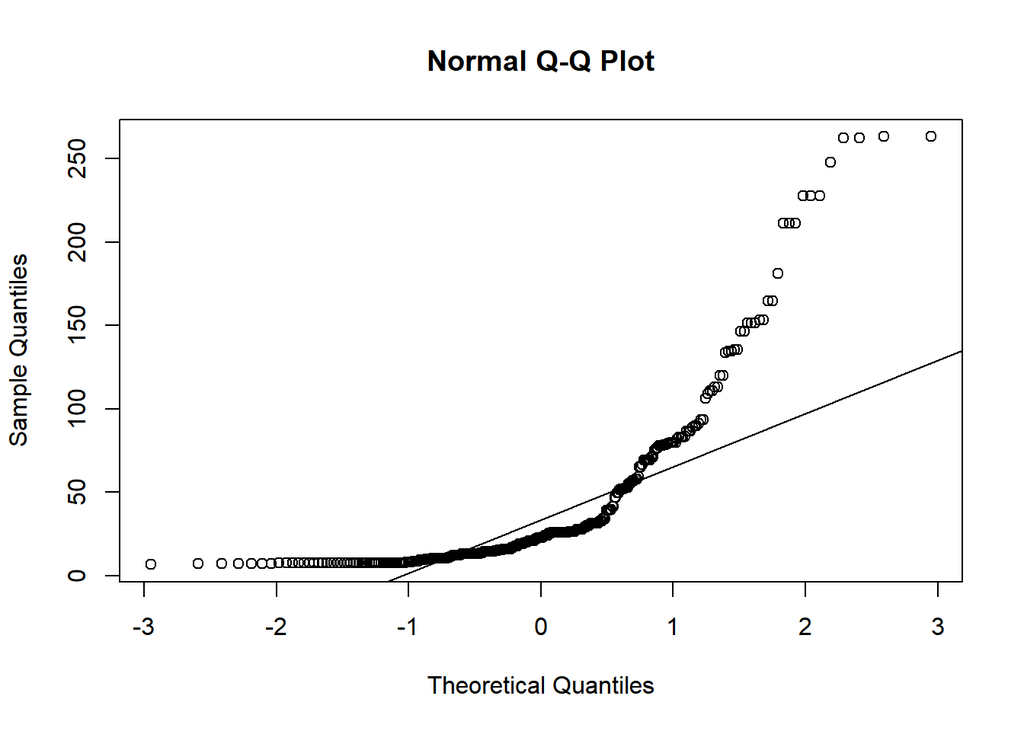

```r
#Se calcula el gráfico QQ para la muestra de mujer
qqnorm(precio.mujer$Fare)
qqline(precio.mujer$Fare)
```

```r
#Se comprueba que no sigue una distribución normal como se comprobó anteriormente

#Se calcula el Test de Shapiro-Wilk para la muestra de hombre
shapiro.test(precio.hombre$Fare)
```

```
##
##  Shapiro-Wilk normality test
##
## data:  precio.hombre$Fare
## W = 0.54863, p-value < 2.2e-16
```

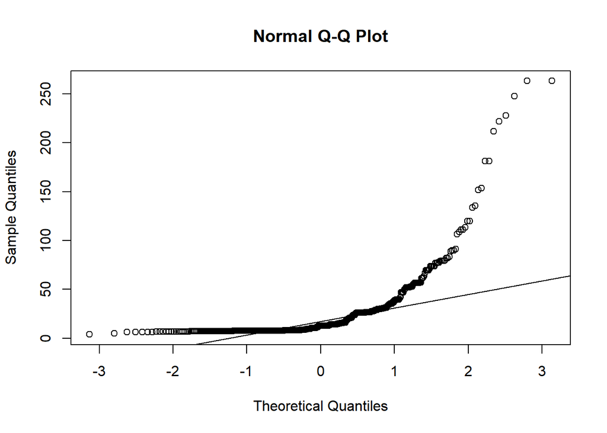

```r
#Se calcula el gráfico QQ para la muestra de hombre
qqnorm(precio.hombre$Fare)
qqline(precio.hombre$Fare)
```

```r
#Se comprueba que no sigue una distribución normal como se comprobó anteriormente

#Se calcula el Test de Shapiro-Wilk para la muestra de primera clase
shapiro.test(precio.primera$Fare)
```

```
##
##  Shapiro-Wilk normality test
##
## data:  precio.primera$Fare
## W = 0.82901, p-value = 1.116e-14
```

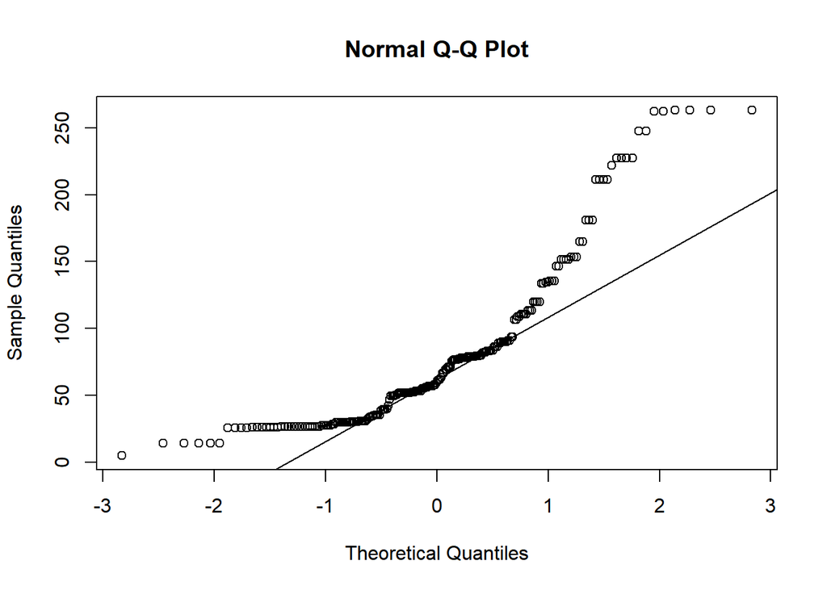

```r
#Se calcula el gráfico QQ para la muestra de primera clase
qqnorm(precio.primera$Fare)
qqline(precio.primera$Fare)
```

```r
#Se comprueba que no sigue una distribución normal como se comprobó anteriormente

#Se calcula el Test de Shapiro-Wilk para la muestra de segunda clase
shapiro.test(precio.segunda$Fare)
```

```
##
##  Shapiro-Wilk normality test
##
## data:  precio.segunda$Fare
## W = 0.72251, p-value < 2.2e-16
```

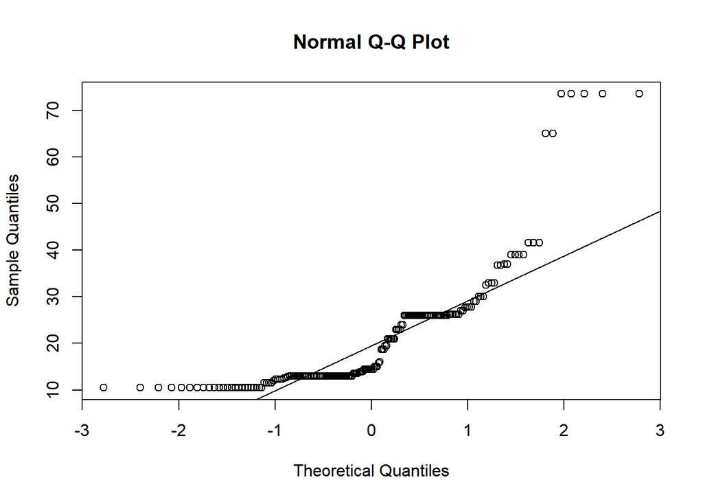

```r
#Se calcula el gráfico QQ para la muestra de segunda clase
qqnorm(precio.segunda$Fare)
qqline(precio.segunda$Fare)
```

```r
#Se comprueba que no sigue una distribución normal como se comprobó anteriormente

#Se calcula el Test de Shapiro-Wilk para la muestra de tercera clase
shapiro.test(precio.tercera$Fare)
```

```
##
##  Shapiro-Wilk normality test
##
## data:  precio.tercera$Fare
## W = 0.60699, p-value < 2.2e-16
```

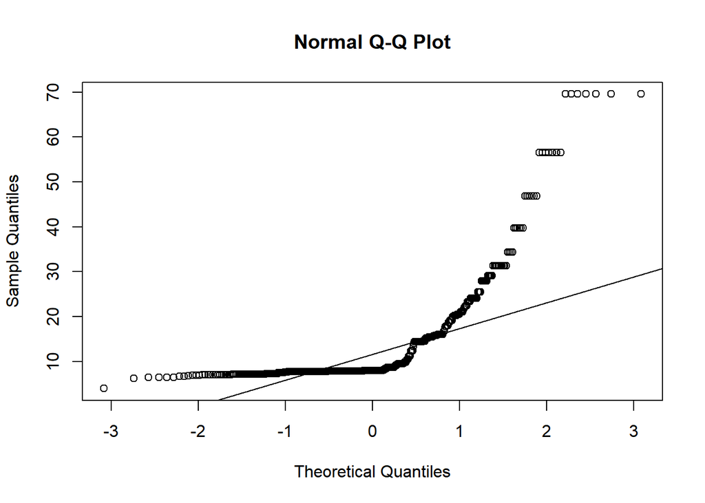

```r
#Se calcula el gráfico QQ para la muestra de tercera clase
qqnorm(precio.tercera$Fare)
qqline(precio.tercera$Fare)
```

```r
#Se comprueba que no sigue una distribución normal como se comprobó anteriormente

#Se calcula el Test de Shapiro-Wilk para la muestra del puerto Queenstrown
shapiro.test(precio.queenstrown$Fare)
```

```
##
##  Shapiro-Wilk normality test
##
## data:  precio.queenstrown$Fare
## W = 0.43638, p-value = 1.151e-15
```

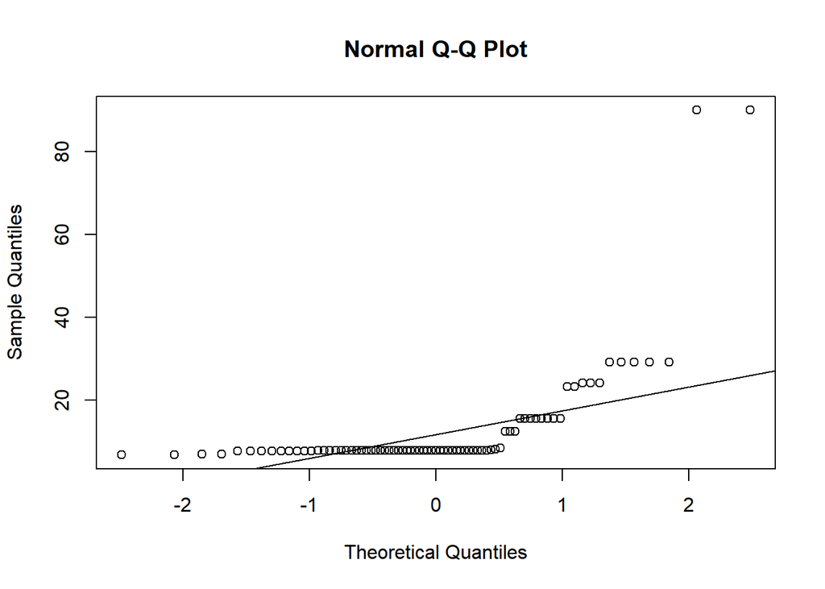

```r
#Se calcula el gráfico QQ para la muestra del puerto Queenstrown
qqnorm(precio.queenstrown$Fare)
qqline(precio.queenstrown$Fare)
```

```r
#Se comprueba que no sigue una distribución normal como se comprobó anteriormente

#Se calcula el Test de Shapiro-Wilk para la muestra del puerto Southampton
shapiro.test(precio.southampton$Fare)
```

```
##
##  Shapiro-Wilk normality test
##
## data:  precio.southampton$Fare
## W = 0.57375, p-value < 2.2e-16
```

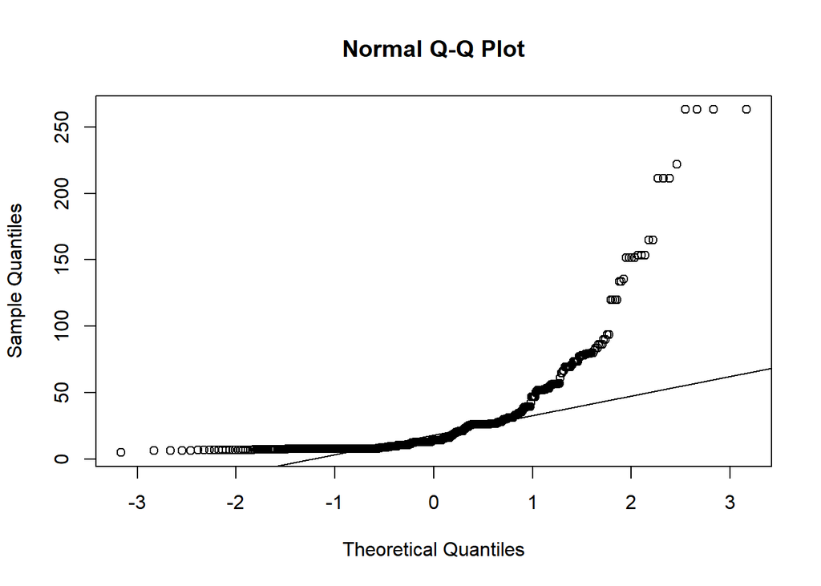

```r
#Se calcula el gráfico QQ para la muestra del puerto Southampton
qqnorm(precio.southampton$Fare)
qqline(precio.southampton$Fare)
```

```r
#Se comprueba que no sigue una distribución normal como se comprobó anteriormente

#Se calcula el Test de Shapiro-Wilk para la muestra del puerto Cherbourg
shapiro.test(precio.cherbourg$Fare)
```

```
##
##  Shapiro-Wilk normality test
##
## data:  precio.cherbourg$Fare
## W = 0.76286, p-value = 3.413e-15
```

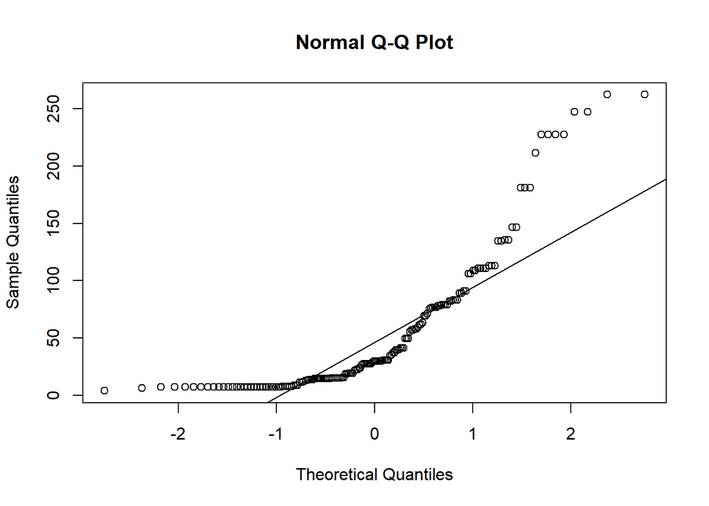

```r
#Se calcula el gráfico QQ para la muestra del puerto Cherbourg
qqnorm(precio.cherbourg$Fare)
qqline(precio.cherbourg$Fare)
```

```r
#Se comprueba que no sigue una distribución normal como se comprobó anteriormente
```

Se va a comprobar la homogeneidad de las varianzas con el Test de Fligner-Killen.

```r
#Se comprueba las varianzas para el precio y la edad
fligner.test(Fare~Age, data=base2)
```

```
##
##  Fligner-Killeen test of homogeneity of variances
##
## data:  Fare by Age
## Fligner-Killeen:med chi-squared = 147.43, df = 87, p-value = 5.634e-05
```

```r
#No se acepta la hipótesis nula (igualdad de varianzas) porque el p-value es menor que alpha (1-0.95)
```

### 4.3 Aplicación de pruebas estadísticas

#### Variables que influyen en el precio y su proporción

Para ello se va a realizar un análisis de correlación entre las distintas variables para determinar las más influyentes. Se procede a calcuar el factor de correlación con el Test de Spearman y su p-valor para comprobar que cumple el nivel de confianza.

```r
corr_matrix <- matrix(nc = 2, nr = 0)
colnames(corr_matrix) <- c("estimado", "p-valor")
#Se van a seleccionar las variables con valores numéricos
borrar2 <- c("Survived","Pclass","Sex","Embarked")
base3 <- base2[ , !(names(base2) %in% borrar2)]
# Calcular el coeficiente de correlación para cada variable cuantitativa con respecto al campo "precio"
for (i in 1:(ncol(base3) - 1)) {
if (is.integer(base3[,i]) | is.numeric(base3[,i])) {
spearman_test = cor.test(base3[,i],base3[,length(base3)], method = "spearman")
corr_coef = spearman_test$estimate
p_val = spearman_test$p.value
# Añadimos las filas a la matriz
pair = matrix(ncol = 2, nrow = 1)
pair[1][1] = corr_coef
pair[2][1] = p_val
corr_matrix <- rbind(corr_matrix, pair)
rownames(corr_matrix)[nrow(corr_matrix)] <- colnames(base3)[i]
corr_matrix
}
}
#Se procede a imprimir los resultados
print(corr_matrix)
```

```
##        estimado      p-valor
## Age   0.1353788 5.034672e-05
## SibSp 0.4427160 4.636445e-44
## Parch 0.4071481 6.711774e-37
```

#### ¿El precio del billete fue superior en caso de ser mujer o hombre?

Se va a realizar un contraste de hipótesis sobre dos muestras para determinar si el precio del billete depende si es mujer o hombre. Se establecen dos variables con los precios si es mujer o hombre. Para poder realizar un análisis de hipótesis se supone que las muestras siguen una distribución normal (n>30 en ambas variables):

```r
precio.mujer.precio <- precio.mujer$Fare
precio.hombre.precio <- precio.hombre$Fare
```

Así, se plantea el siguiente contraste de hipótesis de dos muestras sobre la diferencia de medias, el cual es unilateral atendiendo a la formulación de la hipótesis alternativa: o H0 : µ1 − µ2 = 0 o H1 : µ1 − µ2 < 0 donde µ1 es la media de la población de la que se extrae la primera muestra y µ2 es la media de la población de la que extrae la segunda. Así, tomaremos α = 0, 05.

```r
t.test(precio.mujer.precio,precio.hombre.precio, alternative = "less")
```

```
##
##  Welch Two Sample t-test
##
## data:  precio.mujer.precio and precio.hombre.precio
## t = 5.7377, df = 454.82, p-value = 1
## alternative hypothesis: true difference in means is less than 0
## 95 percent confidence interval:
##      -Inf 24.03752
## sample estimates:
## mean of x mean of y
##  43.42513  24.75175
```

####Modelo de regresión lineal para el precio

Se calcula la variable fare (precio) como explicada y las variables Survived, Pclass, Sex, Age, SibSp, Parch y Embarked como explicativas. Obteniendo:

```r
logit_model_1 <- lm(formula=Fare~factor(Survived)+factor(Pclass)+factor(Sex)+Age+SibSp+Parch+factor(Embarked), data=base2)
summary(logit_model_1)
```

```
##
## Call:
## lm(formula = Fare ~ factor(Survived) + factor(Pclass) + factor(Sex) +
##     Age + SibSp + Parch + factor(Embarked), data = base2)
##
## Residuals:
##     Min      1Q  Median      3Q     Max
## -69.423  -9.232   0.015   4.883 159.665
##
## Coefficients:
##                    Estimate Std. Error t value Pr(>|t|)
## (Intercept)        87.89225    5.01541  17.524  < 2e-16 ***
## factor(Survived)1   0.35172    2.53138   0.139  0.88953
## factor(Pclass)2   -57.25792    3.06090 -18.706  < 2e-16 ***
## factor(Pclass)3   -66.27064    2.80628 -23.615  < 2e-16 ***
## factor(Sex)male    -5.77190    2.47966  -2.328  0.02015 *
## Age                -0.15275    0.08247  -1.852  0.06433 .
## SibSp               5.79461    0.97809   5.924 4.49e-09 ***
## Parch               9.40180    1.34746   6.977 5.91e-12 ***
## factor(Embarked)Q  -7.27062    4.14613  -1.754  0.07985 .
## factor(Embarked)S  -8.43866    2.60489  -3.240  0.00124 **
## ---
## Signif. codes:  0 '***' 0.001 '**' 0.01 '*' 0.05 '.' 0.1 ' ' 1
##
## Residual standard error: 28.53 on 881 degrees of freedom
## Multiple R-squared:  0.5408, Adjusted R-squared:  0.5361
## F-statistic: 115.3 on 9 and 881 DF,  p-value: < 2.2e-16
```

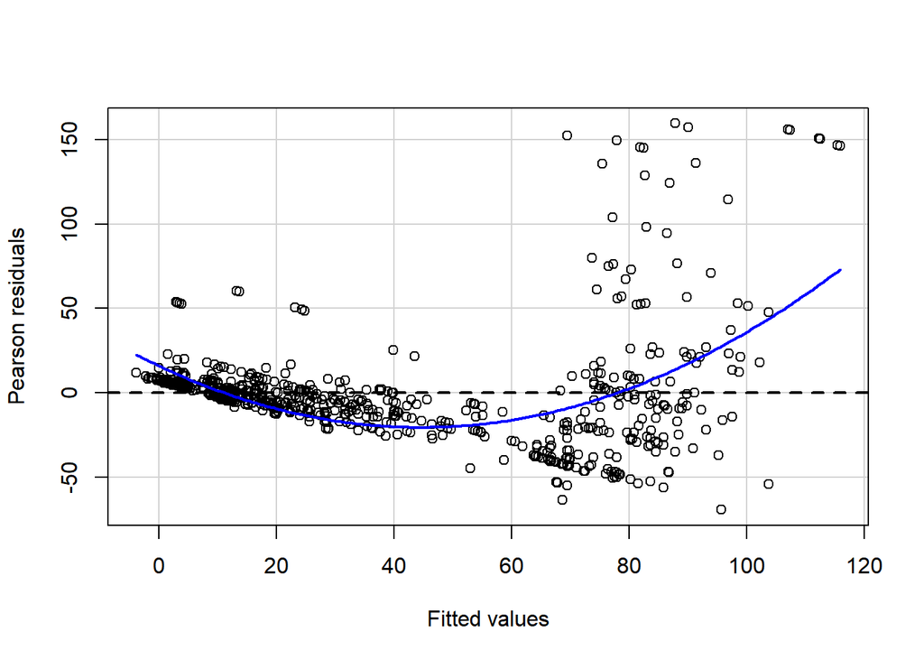

```r
#Se calculan los errores del modelo
residuosmult.cual <- residuals(logit_model_1)
#Se calculan los valores ajustados al modelo
valores.ajustados.mult.cual <-fitted(logit_model_1)
#Se representan los valores estimados frente a los errores
residualPlot(logit_model_1)
```

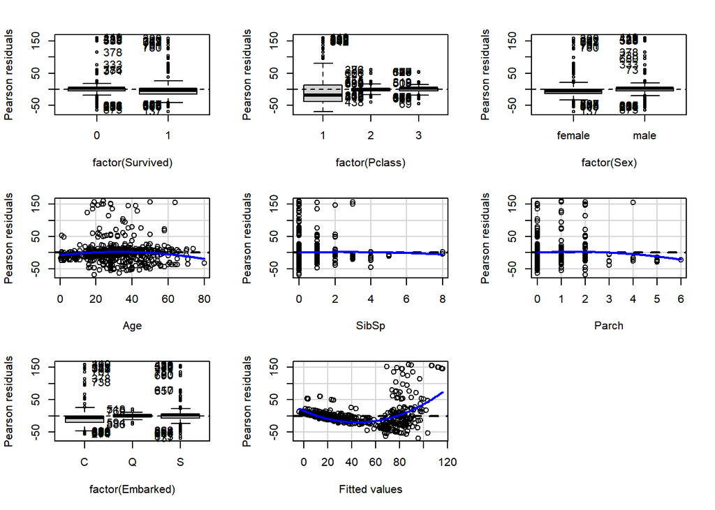

```
##                  Test stat Pr(>|Test stat|)
## factor(Survived)
## factor(Pclass)
## factor(Sex)
## Age                -2.9642         0.003117 **
## SibSp              -0.7993         0.424310
## Parch              -1.8089         0.070806 .
## factor(Embarked)
## Tukey test         17.9338        < 2.2e-16 ***
## ---
## Signif. codes:  0 '***' 0.001 '**' 0.01 '*' 0.05 '.' 0.1 ' ' 1
```

```r
#Se representan los valores de cada variable frente a los errores
residualPlots(logit_model_1)
```

Se procede a predecir el valor de precio con los siguientes valores: o Age = 55 o Survived = 1 o Pclass = 3 o Sex = “male” o SibSp = 0 o Parch = 0 o Embarked = “C”

```r
#Se va a predecir el precio por unos valores determinados
nuevos.valores <- data.frame(Age = 55, Survived = 1, Pclass = 3, Sex = "male", SibSp = 0, Parch = 0, Embarked = "C")
#Calculamos el valor de precio
precioest <-  predict(logit_model_1, nuevos.valores)
precioest
```

```
##        1
## 7.800433
```